# homework3

Kexin Sun

10/10/2020

### Problem 1

```r
data("instacart")
```

Observations are the level of items in orders by user. There are user / order variables – user ID, order ID, order day, and order hour. There are also item variables – name, aisle, department, and some numeric codes.

How many aisles, and which are most items from?

```r
instacart %>%
    count(aisle) %>%
    arrange(desc(n))
```

```
## # A tibble: 134 x 2
##    aisle                              n
##    <chr>                          <int>
##  1 fresh vegetables              150609
##  2 fresh fruits                  150473
##  3 packaged vegetables fruits     78493
##  4 yogurt                         55240
##  5 packaged cheese                41699
##  6 water seltzer sparkling water  36617
##  7 milk                           32644
##  8 chips pretzels                 31269
##  9 soy lactosefree                26240
## 10 bread                          23635
## # … with 124 more rows
```

Let’s make a plot

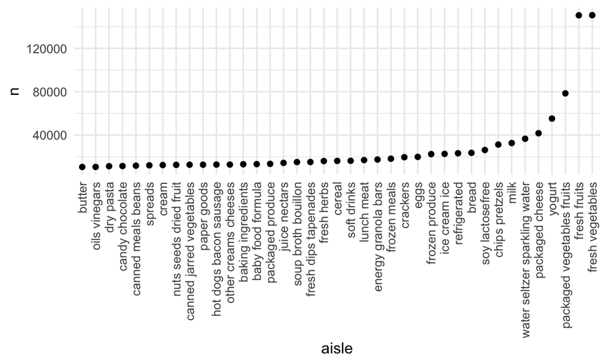

```r
instacart %>%
    count(aisle) %>%
    filter(n > 10000) %>%
    mutate(
        aisle = factor(aisle),
        aisle = fct_reorder(aisle, n)
    ) %>%
    ggplot(aes(x = aisle, y = n)) +
    geom_point() +
    theme(axis.text.x = element_text(angle = 90, vjust = 0.5, hjust = 1))
```

Let’s make a table!!

```r
instacart %>%
    filter(aisle %in% c("baking ingredients", "dog food care", "packaged vegetables fruits")) %>%
    group_by(aisle) %>%
    count(product_name) %>%
    mutate(rank = min_rank(desc(n))) %>%
    filter(rank < 4) %>%
    arrange(aisle, rank) %>%
    knitr::kable()
```

| aisle | product_name | n | rank |
| --- | --- | --- | --- |
| baking ingredients | Light Brown Sugar | 499 | 1 |
| baking ingredients | Pure Baking Soda | 387 | 2 |
| baking ingredients | Cane Sugar | 336 | 3 |
| dog food care | Snack Sticks Chicken & Rice Recipe Dog Treats | 30 | 1 |
| dog food care | Organix Chicken & Brown Rice Recipe | 28 | 2 |
| dog food care | Small Dog Biscuits | 26 | 3 |
| packaged vegetables fruits | Organic Baby Spinach | 9784 | 1 |
| packaged vegetables fruits | Organic Raspberries | 5546 | 2 |
| packaged vegetables fruits | Organic Blueberries | 4966 | 3 |

Apples vs ice cream..

```r
instacart %>%
    filter(product_name %in% c("Pink Lady Apples", "Coffee Ice Cream")) %>%
    group_by(product_name, order_dow) %>%
    summarize(mean_hour = mean(order_hour_of_day)) %>%
    pivot_wider(
        names_from = order_dow,
        values_from = mean_hour
    )
```

```
## # A tibble: 2 x 8
## # Groups:   product_name [2]
##   product_name       `0`   `1`   `2`   `3`   `4`   `5`   `6`
##   <chr>            <dbl> <dbl> <dbl> <dbl> <dbl> <dbl> <dbl>
## 1 Coffee Ice Cream  13.8  14.3  15.4  15.3  15.2  12.3  13.8
## 2 Pink Lady Apples  13.4  11.4  11.7  14.2  11.6  12.8  11.9
```

## Problem 2

```r
accel_df =
  read_csv ("./data/accel_data.csv") %>%
  janitor::clean_names() %>%
  pivot_longer(
    activity_1:activity_1440,
    names_prefix = "activity_",
    names_to = "minute",
    values_to = "count"
    )%>%
  mutate(
    day = factor(day),
    count = as.numeric(count),
    minute = as.numeric(minute),
    day_id = as.numeric(day_id),
    weekday_or_weekend = case_when(
      day %in% c("Saturday", "Sunday") ~ "Weekend",
      day %in% c("Monday", "Tuesday", "Wednesday", "Thursday", "Friday") ~ "Weekday"))
```

There are 6 variables and 50400 observations in this data set, and variables are “week, day_id, day, minute, count, weekday_or_weekend”.

```r
accel_df2=
  accel_df %>%
  group_by(week, day) %>%
  summarize(
    total_activity_count = sum(count)
  ) %>%
  pivot_wider(
    names_from = day,
    values_from = total_activity_count
  ) %>%
  relocate(week, Monday, Tuesday, Wednesday,Thursday, Friday, Saturday, Sunday) %>%
  knitr::kable(digits = 2)
accel_df =
  accel_df %>%
  group_by(week) %>%
  arrange(day, .by_group = TRUE) %>%
  group_by(day_id) %>%
  mutate(min_week = 1,
         hour = cumsum(min_week) %/% 60) %>%
  ungroup(day_id) %>%
  select(-min_week)
```

```r
activity_plot =
  accel_df %>%
  group_by(day_id, day, hour) %>%
  summarize(activity_counts_hr = sum(count, na.rm = TRUE)) %>%
  ggplot(aes(x = hour, y = activity_counts_hr, color = day, group = day_id)) +
  geom_line(alpha = 0.2, size = 0.4) +
  stat_smooth(se = FALSE, geom = "line") +
  scale_x_continuous(limits = c(0,24), breaks = seq(0,24,2)) +
  scale_y_continuous(limits = c(-10000, 60000), breaks = seq(-10000, 60000, 10000)) +
  labs(
    title = "Hourly activity counts in 35 days",
    x = "Hour",
    y = "Total activity counts"
  )
```

## Problem 3

```r
library(p8105.datasets)
data("ny_noaa")
```

```r
library(readxl)
library(dplyr)
library(rnoaa)
library(ggridges)
library(patchwork)
```

```r
ny_noaa_df =
  ny_noaa %>%
  mutate_at(vars(date), as.factor) %>%
  separate(date, into = c("year", "month", "day")) %>%
  mutate_at(vars(prcp, tmax, tmin, snow), as.numeric) %>%
  mutate(
      prcp = prcp/10,
      tmax = tmax/10,
      tmin = tmin/10,
      snow = case_when(
      snow <0 ~ 0,
      snow >= 0 ~ snow)
  ) %>%
  mutate_at(vars(year, month, day), as.factor)
skimr::skim_without_charts(ny_noaa_df)
```

Data summary

| Name | ny_noaa_df |
| --- | --- |
| Number of rows | 2595176 |
| Number of columns | 9 |
| _______________________ |  |
| Column type frequency: |  |
| character | 1 |
| factor | 3 |
| numeric | 5 |
| ________________________ |  |
| Group variables | None |

**Variable type: character**

| skim_variable | n_missing | complete_rate | min | max | empty | n_unique | whitespace |
| --- | --- | --- | --- | --- | --- | --- | --- |
| id | 0 | 1 | 11 | 11 | 0 | 747 | 0 |

**Variable type: factor**

| skim_variable | n_missing | complete_rate | ordered | n_unique | top_counts |
| --- | --- | --- | --- | --- | --- |
| year | 0 | 1 | FALSE | 30 | 201: 159671, 200: 148721, 200: 122665, 200: 93249 |
| month | 0 | 1 | FALSE | 12 | 10: 224471, 12: 223603, 07: 220348, 08: 220100 |
| day | 0 | 1 | FALSE | 31 | 01: 85258, 02: 85258, 03: 85258, 04: 85258 |

**Variable type: numeric**

| skim_variable | n_missing | complete_rate | mean | sd | p0 | p25 | p50 | p75 | p100 |
| --- | --- | --- | --- | --- | --- | --- | --- | --- | --- |
| prcp | 145838 | 0.94 | 2.98 | 7.82 | 0.0 | 0.0 | 0.0 | 2.3 | 2286 |
| snow | 381221 | 0.85 | 4.99 | 27.22 | 0.0 | 0.0 | 0.0 | 0.0 | 10160 |
| snwd | 591786 | 0.77 | 37.31 | 113.54 | 0.0 | 0.0 | 0.0 | 0.0 | 9195 |
| tmax | 1134358 | 0.56 | 13.98 | 11.14 | -38.9 | 5.0 | 15.0 | 23.3 | 60 |
| tmin | 1134420 | 0.56 | 3.03 | 10.40 | -59.4 | -3.9 | 3.3 | 11.1 | 60 |

There are 9 variables and 2595176 observations in this data set, and variables are “id, year, month, day, prcp, snow, snwd, tmax, tmin”.

```r
ny_noaa_df %>%
  count(snow) %>%
  arrange(desc(n))
```

```
## # A tibble: 281 x 2
##     snow       n
##    <dbl>   <int>
##  1     0 2008509
##  2    NA  381221
##  3    25   31022
##  4    13   23095
##  5    51   18274
##  6    76   10173
##  7     8    9962
##  8     5    9748
##  9    38    9197
## 10     3    8790
## # … with 271 more rows
```

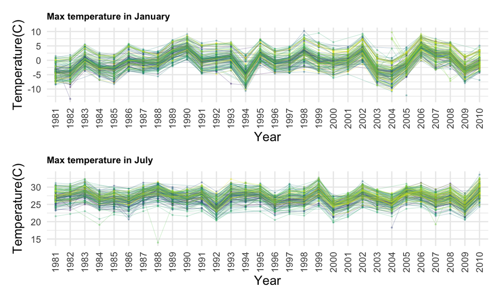

```r
Figure1 =
  ny_noaa_df %>%
  filter(month == "01") %>%
  group_by(id,year,month) %>%
  summarise(tmax_mean = mean(tmax,na.rm = T)) %>%
  drop_na() %>%
  ggplot(aes(x = year, y = tmax_mean, color = id)) +
  geom_point(alpha = 0.3, size = 0.2) +
  geom_path(aes(group = id), alpha = 0.3, size = 0.2) +
  theme(
    legend.position = 'none',
    plot.title = element_text(lineheight = 3, face = "bold", color = "black", size = 8),
    axis.text.x = element_text(angle = 90, vjust = 0.5, hjust = 1, size = 8),
    axis.text.y = element_text(size = 8)
    ) +
  labs(
    x = "Year",
    y = "Temperature(C)",
    title = "Max temperature in January"
    )
 Figure2 =
  ny_noaa_df %>%
  filter(month == "07") %>%
  group_by(id,year,month) %>%
  summarise(tmax_mean = mean(tmax,na.rm = T)) %>%
  drop_na() %>%
  ggplot(aes(x = year, y = tmax_mean, color = id)) +
  geom_point(alpha = 0.3, size = 0.2) +
  geom_path(aes(group = id), alpha = 0.3, size = 0.2) +
  theme(
    legend.position = 'none',
    plot.title = element_text(lineheight = 3, face = "bold", color = "black", size = 8),
    axis.text.x = element_text(angle = 90, vjust = 0.5, hjust = 1, size = 8),
    axis.text.y = element_text(size = 8)
    ) +
  labs(
    x = "Year",
    y = "Temperature(C)",
    title = "Max temperature in July"
    )
 Figure1/Figure2
```

There are eight outliers in January:

```r
ny_noaa_df %>%
  filter(month == "01") %>%
  group_by(id,year,month) %>%
  summarise(tmax_mean = mean(tmax,na.rm = T)) %>%
  drop_na() %>%
  filter(tmax_mean > 10 | tmax_mean < -10) %>%
  knitr::kable(digits = 1)
```

| id | year | month | tmax_mean |
| --- | --- | --- | --- |
| USC00301723 | 1982 | 01 | -13.4 |
| USC00303464 | 1998 | 01 | 10.2 |
| USC00304996 | 1994 | 01 | -10.6 |
| USC00305925 | 2005 | 01 | -12.2 |
| USC00306957 | 2004 | 01 | -10.8 |
| USW00094725 | 1994 | 01 | -10.2 |
| USW00094725 | 2004 | 01 | -10.4 |
| USW00094740 | 2004 | 01 | -10.4 |

There are seven outliers in July:

```r
ny_noaa_df %>%
  filter(month == "07") %>%
  group_by(id,year,month) %>%
  summarise(tmax_mean = mean(tmax,na.rm = T)) %>%
  drop_na() %>%
  filter(tmax_mean > 33 | tmax_mean < 20) %>%
  knitr::kable(digits = 1)
```

| id | year | month | tmax_mean |
| --- | --- | --- | --- |
| USC00302454 | 2004 | 07 | 18.3 |
| USC00305377 | 2010 | 07 | 33.6 |
| USC00306957 | 2000 | 07 | 19.8 |
| USC00308248 | 2000 | 07 | 19.9 |
| USC00308946 | 1984 | 07 | 19.1 |
| USC00308962 | 1988 | 07 | 14.0 |
| USC00309389 | 2007 | 07 | 19.2 |

Grouped Boxplot is used to compare the max and min of temperature in the whole dataset.

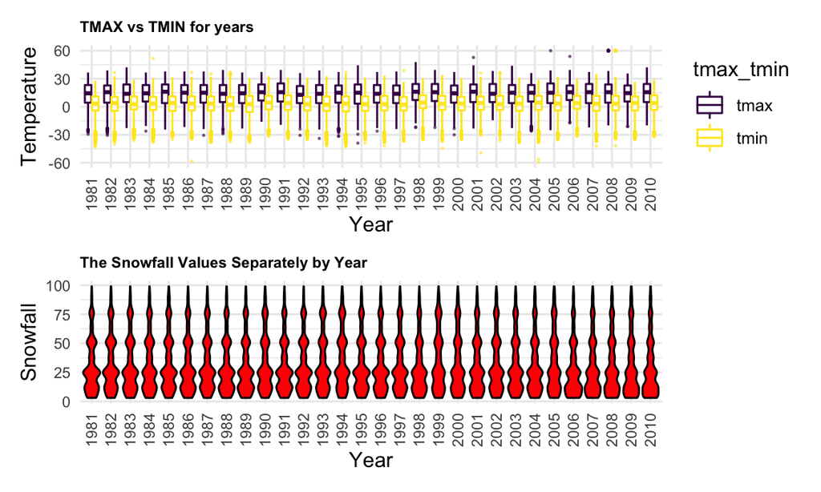

```r
temperature =
  ny_noaa_df %>%
  drop_na(tmax, tmin) %>%
  pivot_longer(
    tmax:tmin,
    names_to = "tmax_tmin",
    values_to = "temp"
  ) %>%
  ggplot(aes(x = year, y = temp)) +
  geom_boxplot(aes(color = tmax_tmin), alpha = 0.5, outlier.size = 0.2) +
  theme(
    plot.title = element_text(lineheight = 3, face = "bold", color = "black", size = 8),
    legend.position = 'right',
    axis.text.x = element_text(angle = 90, vjust = 0.5, hjust = 1, size = 8),
    axis.text.y = element_text(size = 8)
    ) +
  labs(
    x = "Year",
    y = "Temperature",
    title = "TMAX vs TMIN for years"
    )

snowfall =
  ny_noaa_df %>%
  filter(snow > 0 & snow < 100) %>%
  ggplot(aes(x = year, y = snow)) +
  geom_violin(color = "black" , fill = "red") +
  theme(
    plot.title = element_text(lineheight = 3, face = "bold", color = "black", size = 8),
    axis.text.x = element_text(angle = 90, vjust = 0.5, hjust = 1, size = 8),
    axis.text.y = element_text(size = 8)) +
  labs(
    x = "Year",
    y = "Snowfall",
    title = "The Snowfall Values Separately by Year"
    )

temperature / snowfall
```